# 6 Improving Stability

#### Mix in even more distorted data

As you can see on the loss curve, the model is now again able to learn after mixing in a certain number of distorted images. So, we start the next round training the model with mixing in even more distorted data.

Again, we take a certain number of random samples (n) and add noise to the one half and apply the transformation to the other half. Note, that this time we apply the distortions to the already distorted dataset. Most likely, this leads to an overall increase of distorted images (either noisy or transformed). On the other side, this approach can result in a training set in which some images are noisy and transformed, two times added with noise, or two times transformed.

Consequently, the training set is even more distorted to again enable learning of the model.

```python
# mix in again n images in training data
n = 10000

# choose n random indices without duplicates
indices_rand = random.sample(range(0, x_train.shape[0]), n)
#print(len(indices_rand))

# add gaussian noise to half of the images
x_train_noisy[indices_rand[:int(n/2)]] = addGaussianNoise(x_train_noisy[indices_rand[:int(n/2)]], 0.0, 1.0, 0.1)

# transform other half of the images
for i in range(int(n/2), len(indices_rand)):
    x_train_noisy[indices_rand[i]] = distortImg(x_train_noisy[indices_rand[i]])
```

#### And again Retraining

```python
history = autoencoder.fit(x_train_noisy, x_train,
                epochs=100,
                batch_size=32,
                verbose=1,
                shuffle=True,
                validation_data=(x_test, x_test),
                validation_split = 0.2,
                callbacks=[es_cb, cp_cb, tensorboard_callback]
               )
```

```
Epoch 00001: val_loss did not improve from 0.02041

Epoch 00002: val_loss improved from 0.02041 to 0.02035, saving model to ./models/checkpoints/AutoEncoder_Cifar10_Deep_weights_improved_stability.02-0.02-0.02.hdf5

Epoch 00003: val_loss did not improve from 0.02035

Epoch 00004: val_loss did not improve from 0.02035

Epoch 00005: val_loss improved from 0.02035 to 0.02028, saving model to ./models/checkpoints/AutoEncoder_Cifar10_Deep_weights_improved_stability.05-0.02-0.02.hdf5

Epoch 00006: val_loss did not improve from 0.02028

Epoch 00007: val_loss did not improve from 0.02028

Epoch 00008: val_loss did not improve from 0.02028
Epoch 00008: early stopping
```

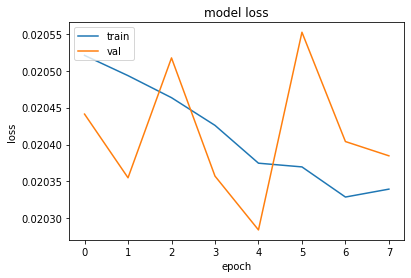

```python
plt.plot(history.history['loss'])
plt.plot(history.history['val_loss'])
plt.title('model loss')
plt.ylabel('loss')
plt.xlabel('epoch')
plt.legend(['train', 'val'], loc='upper left')
plt.show()
```

#### And again mix in data

```python
# mix in again n images in training data
n = 40000

# choose n random indices without duplicates
indices_rand = random.sample(range(0, x_train.shape[0]), n)

# add gaussian noise to half of the images
x_train_noisy[indices_rand[:int(n/2)]] = addGaussianNoise(x_train_noisy[indices_rand[:int(n/2)]], 0.0, 1.0, 0.1)

# transform other half of the images
for i in range(int(n/2), len(indices_rand)):
    x_train_noisy[indices_rand[i]] = distortImg(x_train_noisy[indices_rand[i]])
```

### Retraining again

```python
history = autoencoder.fit(x_train_noisy, x_train,
                epochs=100,
                batch_size=32,
                verbose=1,
                shuffle=True,
                validation_data=(x_test, x_test),
                validation_split = 0.2,
                callbacks=[es_cb, cp_cb, tensorboard_callback]
               )
```

```
Epoch 00001: val_loss did not improve from 0.02028

Epoch 00002: val_loss did not improve from 0.02028

Epoch 00003: val_loss did not improve from 0.02028

Epoch 00004: val_loss did not improve from 0.02028

Epoch 00005: val_loss did not improve from 0.02028

Epoch 00006: val_loss did not improve from 0.02028

Epoch 00007: val_loss did not improve from 0.02028

Epoch 00008: val_loss did not improve from 0.02028
Epoch 00008: early stopping
```

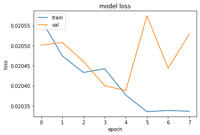

```python
plt.plot(history.history['loss'])
plt.plot(history.history['val_loss'])
plt.title('model loss')
plt.ylabel('loss')
plt.xlabel('epoch')
plt.legend(['train', 'val'], loc='upper left')
plt.show()
```

#### Save Model

```python
autoencoder.save('models/autoencoder_improvedStability.hdf5')
encoder.save('models/encoder_improvedStability.hdf5')
```

```
WARNING:tensorflow:Compiled the loaded model, but the compiled metrics have yet to be built. `model.compile_metrics` will be empty until you train or evaluate the model.
```